# Continuous Data Analysis Demo 2 — ANOVA

Professor Christopher J. Schmank

2024-11-11

```r
# install.packages("datarium")
# install.packages("rstatix")
# install.packages("ggpubr")

library(jmv)
library(psych)
library(tidyverse)
library(infer)
library(datarium)
library(rstatix)
library(ggpubr)
```

## Repeated-Measures (Within-Subject) ANOVA

Single DV collected multiple times from Ss

**Research Question 1**: Are the self-esteem means different across the three time points for our participants?

```r
# Load and inspect demo data set(s)

# Load `mice` data from `datarium` package
data(selfesteem, package="datarium")
head(selfesteem)
```

```
## # A tibble: 6 × 4
##      id    t1    t2    t3
##   <int> <dbl> <dbl> <dbl>
## 1     1  4.01  5.18  7.11
## 2     2  2.56  6.91  6.31
## 3     3  3.24  4.44  9.78
## 4     4  3.42  4.71  8.35
## 5     5  2.87  3.91  6.46
## 6     6  2.05  5.34  6.65
```

**Hypothesis Statement**: 2-tailed (Non-directional)

$H_0$: Null Hypothesis — Self-esteem means are not different across time, $\mu_{Time1} = \mu_{Time2} = \mu_{Time3}$

$H_a$: Alternate Hypothesis — At least one mean ($\mu$) differs from another

## Descriptive Statistics (Do not forget to visualize!!)

First, we will change the format from wide to long!

```r
selfesteemB <- selfesteem %>%
  gather(key = "time", value = "selfest", t1, t2, t3) %>%
  convert_as_factor(id, time)
head(selfesteemB, 3)
```

```
## # A tibble: 3 × 3
##   id    time  selfest
##   <fct> <fct>   <dbl>
## 1 1     t1       4.01
## 2 2     t1       2.56
## 3 3     t1       3.24
```

```r
#Descriptive statistics for `self-esteem` variable across `time`
describeBy(selfesteemB$selfest, group=selfesteemB$time, mat=TRUE)
```

```
##     item group1 vars  n     mean        sd   median  trimmed       mad      min
## X11    1     t1    1 10 3.140122 0.5518061 3.211833 3.168791 0.4524076 2.045868
## X12    2     t2    1 10 4.933942 0.8630697 4.600536 4.814760 0.6019745 3.908429
## X13    3     t3    1 10 7.636342 1.1425976 7.463227 7.534572 1.4009361 6.308434
##          max    range       skew    kurtosis        se
## X11 4.005027 1.959159 -0.4466668 -0.67017272 0.1744964
## X12 6.912915 3.004487  1.0074034  0.05150281 0.2729266
## X13 9.778410 3.469977  0.4046384 -1.29566568 0.3613211
```

## `jmv` Repeated Measures ANOVA

```r
selfesteem %>%
  anovaRM(rm = list(list(
    label = 'Timing',
    levels = c('Time1','Time2','Time3'))),
         rmCells = list(
           list(
             measure = 't1',
             cell = 'Time1'),
           list(
             measure = 't2',
             cell = 'Time2'),
           list(
             measure = 't3',
             cell = 'Time3')),
    rmTerms = list('Timing'),
    effectSize = 'eta',
    spherTests = TRUE,
    postHoc = 'Timing',
    postHocCorr = 'bonf')
```

```
##
##  REPEATED MEASURES ANOVA
##
##  Within Subjects Effects
##  ──────────────────────────────────────────────────────────────────────────────────────────
##                Sum of Squares    df    Mean Square    F           p             η²
##  ──────────────────────────────────────────────────────────────────────────────────────────
##    Timing           102.45582     2     51.2279125    55.46903    < .0000001    0.8285954
##    Residual          16.62374    18      0.9235409
##  ──────────────────────────────────────────────────────────────────────────────────────────
##    Note. Type 3 Sums of Squares
##
##
##  Between Subjects Effects
##  ──────────────────────────────────────────────────────────────────────────────────
##                Sum of Squares    df    Mean Square    F    p            η²
##  ──────────────────────────────────────────────────────────────────────────────────
##    Residual          4.570442     9      0.5078269
##  ──────────────────────────────────────────────────────────────────────────────────
##    Note. Type 3 Sums of Squares
##
##
##  ASSUMPTIONS
##
##  Tests of Sphericity
##  ───────────────────────────────────────────────────────────────────────────────
##              Mauchly's W    p            Greenhouse-Geisser ε    Huynh-Feldt ε
##  ───────────────────────────────────────────────────────────────────────────────
##    Timing      0.5508534    0.0920755               0.6900613        0.7743711
##  ───────────────────────────────────────────────────────────────────────────────
##
##
##  POST HOC TESTS
##
##  Post Hoc Comparisons - Timing
##  ───────────────────────────────────────────────────────────────────────────────────────────────────
##    Timing         Timing    Mean Difference    SE           df          t             p-bonferroni
##  ───────────────────────────────────────────────────────────────────────────────────────────────────
##    Time1     -    Time2           -1.793820    0.3611027    9.000000     -4.967618       0.0023173
##              -    Time3           -4.496220    0.3398979    9.000000    -13.228148       0.0000010
##    Time2     -    Time3           -2.702400    0.5551565    9.000000     -4.867816       0.0026586
##  ───────────────────────────────────────────────────────────────────────────────────────────────────
```

## Assumption Checks

```r
selfesteemB %>%
  group_by(time) %>%
  shapiro_test(selfest)
```

```
## # A tibble: 3 × 4
##   time  variable statistic     p
##   <fct> <chr>        <dbl> <dbl>
## 1 t1    selfest      0.967 0.859
## 2 t2    selfest      0.876 0.117
## 3 t3    selfest      0.923 0.380
```

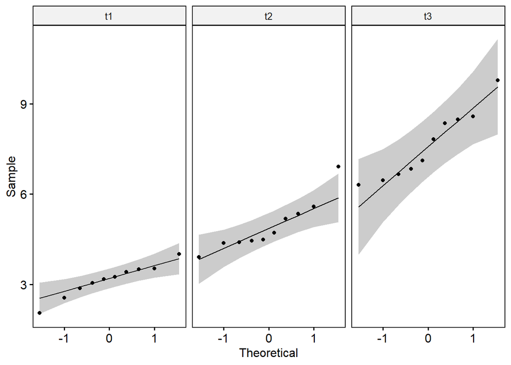

```r
ggqqplot(selfesteemB, "selfest", facet.by = "time")
```

# Running the RM ANOVA

```r
rmanova <- anova_test(data = selfesteemB,
                      dv = selfest,
                      wid = id,
                      within = time)

get_anova_table(rmanova)
```

```
## ANOVA Table (type III tests)
##
##   Effect DFn DFd      F        p p<.05   ges
## 1   time   2  18 55.469 2.01e-08     * 0.829
```

# Pairwise Comparisons — Post Hoc Analyses

```r
pwc <- selfesteemB %>%
  pairwise_t_test(
    selfest ~ time, paired = TRUE,
    p.adjust.method = "bonferroni"
    )
pwc
```

```
## # A tibble: 3 × 10
##   .y.     group1 group2    n1    n2 statistic    df         p p.adj p.adj.signif
## * <chr>   <chr>  <chr>  <int> <int>     <dbl> <dbl>     <dbl> <dbl> <chr>
## 1 selfest t1     t2        10    10     -4.97     9   7.72e-4  2e-3 **
## 2 selfest t1     t3        10    10    -13.2      9   3.34e-7  1e-6 ****
## 3 selfest t2     t3        10    10     -4.87     9   8.86e-4  3e-3 **
```

## Publishable Plot | Using `rstatix` and `ggpubr` packages

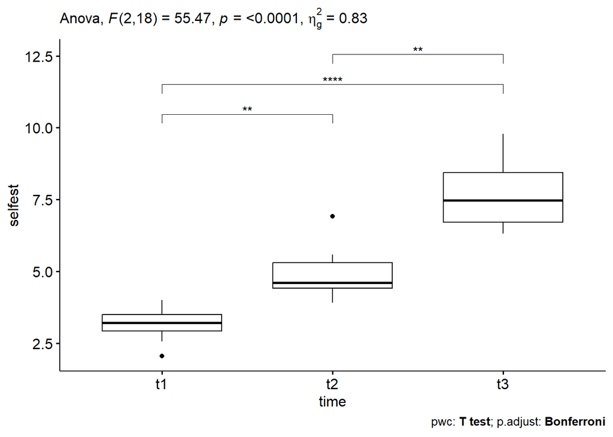

```r
pwc <- pwc %>% add_xy_position(x = "time")

bxp <- ggboxplot(selfesteemB, x = "time", y = "selfest") +
  stat_pvalue_manual(pwc) +
  labs(
    subtitle = get_test_label(rmanova, detailed = TRUE),
    caption = get_pwc_label(pwc)
  )

bxp
```